# Git & Github, Part 1

October 15, 2015

## What's the DataLab?

- New lab in the School of Social Work
- Bringing a more data-scientific approach to social science
- Emphasisis on open source tools (R, Git, Github, etc.)
- Led by Bryan Perron and Joe Ryan (rad dudes)

## Who am I?

- Data/Software nerd
- Data Engineer/Business Intelligence Analyst @ Barracuda Networks
- Co-Organizer of the Ann Arbor R User Group
- Consultant for DataLab (the non-academic one)
- Math Degree from Michigan Tech

## What to expect

- Mixture of slides and demonstration
- Basics of Git (software tool) & Github (website)
- Stop me! Ask questions!
- Help me help you!

## Change Tracking & Source Control

- Because appending numbers to document names is so 2000!
- Google Docs, MS Office, etc. have some change tracking built-in
- Tools like SVN, Mercurial, Git are best suited for *plaintext* documents, like source code
- Gives a change history allowing you to revert to old version, see who broke it, etc.

## What's Git?

- Distributed version control system
- Created by Linus Torvalds to manage Linux development
- Efficient, flexible, popular, mature
- Complex, but it doesn't have to be difficult

## Git Basics & Terminology

- A git **repository** tracks a single *project*
- A repository has one or more **branches** which each contain one or more **commits**
- A **commit** is a record of *changes* from the previous commit (which might be empty)

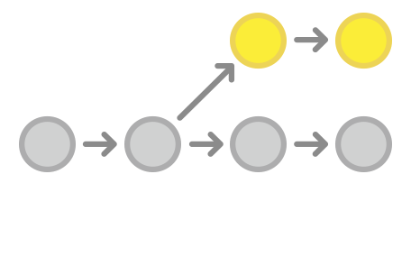

## Simplest Git workflow

- Make commits to a single branch (`master`)
- This gives us reviewable history (`git log`)
- Review changes before commit (`git diff`)

## (Git demo)

## Github

- Hosting service for Git repositories (centralization)
- Users **push**/**pull** between their local repo and the remote repo on Github
- The most popular host for open-source software projects
- Adds a ton of nice features on top of issues like bug/issue tracking, code review, etc.
- Difficult to understate the value of Github in modern software development

## (Github demo)

## Questions?

## What about Part 2?

- Collaborative workflow with branches and code review pull requests
- What should/should not be committed to a repo
- `README.md`, `.gitignore`, and other best practices
- Two weeks from now, October 29, same time & place

## Ann Arbor R User Group

- Next meetup is tonight, 7pm @ Barracuda Networks on Maynard
- http://www.meetup.com/Ann-Arbor-R-User-Group/events/225716211/